# Darshan_Real Estate

```python
df_train['pop_bins']=pd.cut(df_train['pop'],bins=5,labels=['very low','low','medium','high','very high'])
```

```python
df_train[['pop','pop_bins']]
```

|  | pop | pop_bins |
| --- | --- | --- |
| 0 | 5230 | very low |
| 1 | 2633 | very low |
| 2 | 6881 | very low |
| 3 | 2700 | very low |
| 4 | 5637 | very low |
| ... | ... | ... |
| 27316 | 1847 | very low |
| 27317 | 4155 | very low |
| 27318 | 2829 | very low |
| 27319 | 11542 | low |
| 27320 | 3726 | very low |

27321 rows × 2 columns

```python
df_train['pop_bins'].value_counts()
```

```
very low     27058
low            246
medium           9
high             7
very high        1
Name: pop_bins, dtype: int64
```

Analyze the married, separated, and divorced population for these population brackets

```python
df_train.groupby(by='pop_bins')[['married','separated','divorced']].count()
```

| pop_bins | married | separated | divorced |
| --- | --- | --- | --- |
| very low | 27058 | 27058 | 27058 |
| low | 246 | 246 | 246 |
| medium | 9 | 9 | 9 |
| high | 7 | 7 | 7 |
| very high | 1 | 1 | 1 |

```python
df_train.groupby(by='pop_bins')[['married','separated','divorced']].agg(["mean", "median"])
```

| pop_bins | married mean | married median | separated mean | separated median | divorced mean | divorced median |
| --- | --- | --- | --- | --- | --- | --- |
| very low | 0.507548 | 0.524680 | 0.019126 | 0.013650 | 0.100504 | 0.096020 |
| low | 0.584894 | 0.593135 | 0.015833 | 0.011195 | 0.075348 | 0.070045 |
| medium | 0.655737 | 0.618710 | 0.005003 | 0.004120 | 0.065927 | 0.064890 |
| high | 0.503359 | 0.335660 | 0.008141 | 0.002500 | 0.039030 | 0.010320 |
| very high | 0.734740 | 0.734740 | 0.004050 | 0.004050 | 0.030360 | 0.030360 |

Visualize using appropriate chart type

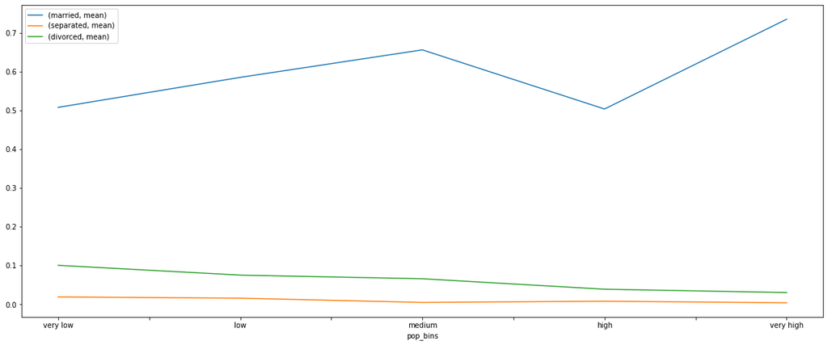

```python
plt.figure(figsize=(10,5))
pop_bin_married=df_train.groupby(by='pop_bins')[['married','separated','divorced']].agg(["mean"])
pop_bin_married.plot(figsize=(20,8))
plt.legend(loc='best')
plt.show()
```

Please detail your observations for rent as a percentage of income at an overall level, and for different states.

```python
rent_state_mean=df_train.groupby(by='state')['rent_mean'].agg(["mean"])
rent_state_mean.head()
```

| state | mean |
| --- | --- |
| Alabama | 774.004927 |
| Alaska | 1185.763570 |
| Arizona | 1097.753511 |
| Arkansas | 720.918575 |
| California | 1471.133857 |

```python
income_state_mean=df_train.groupby(by='state')['family_mean'].agg(["mean"])
income_state_mean.head()
```

| state | mean |
| --- | --- |
| Alabama | 67030.064213 |
| Alaska | 92136.545109 |
| Arizona | 73328.238798 |
| Arkansas | 64765.377850 |
| California | 87655.470820 |

```python
rent_perc_of_income=rent_state_mean['mean']/income_state_mean['mean']
rent_perc_of_income.head(10)
```

```
state
Alabama                 0.011547
Alaska                  0.012870
Arizona                 0.014970
Arkansas                0.011131
California              0.016783
Colorado                0.013529
Connecticut             0.012637
Delaware                0.012929
District of Columbia    0.013198
Florida                 0.015772
Name: mean, dtype: float64
```

```python
#overall level rent as a percentage of income
sum(df_train['rent_mean'])/sum(df_train['family_mean'])
```

```
0.013358170721473864
```

Perform correlation analysis for all the relevant variables by creating a heatmap. Describe your findings.

```python
df_train.columns
```

```
Index(['UID', 'COUNTYID', 'STATEID', 'state', 'state_ab', 'city', 'place',
       'type', 'primary', 'zip_code', 'area_code', 'lat', 'lng', 'ALand',
       'AWater', 'pop', 'male_pop', 'female_pop', 'rent_mean', 'rent_median',
       'rent_stdev', 'rent_sample_weight', 'rent_samples', 'rent_gt_10',
       'rent_gt_15', 'rent_gt_20', 'rent_gt_25', 'rent_gt_30', 'rent_gt_35',
       'rent_gt_40', 'rent_gt_50', 'universe_samples', 'used_samples',
       'hi_mean', 'hi_median', 'hi_stdev', 'hi_sample_weight', 'hi_samples',
       'family_mean', 'family_median', 'family_stdev', 'family_sample_weight',
       'family_samples', 'hc_mortgage_mean', 'hc_mortgage_median',
       'hc_mortgage_stdev', 'hc_mortgage_sample_weight', 'hc_mortgage_samples',
       'hc_mean', 'hc_median', 'hc_stdev', 'hc_samples', 'hc_sample_weight',
       'home_equity_second_mortgage', 'second_mortgage', 'home_equity', 'debt',
       'second_mortgage_cdf', 'home_equity_cdf', 'debt_cdf', 'hs_degree',
       'hs_degree_male', 'hs_degree_female', 'male_age_mean',
       'male_age_median', 'male_age_stdev', 'male_age_sample_weight',
       'male_age_samples', 'female_age_mean', 'female_age_median',
       'female_age_stdev', 'female_age_sample_weight', 'female_age_samples',
       'pct_own', 'married', 'married_snp', 'separated', 'divorced',
       'bad_debt', 'bins', 'pop_density', 'age_median', 'pop_bins'],
      dtype='object')
```

```python
cor=df_train[['COUNTYID','STATEID','zip_code','type','pop', 'family_mean',
         'second_mortgage', 'home_equity', 'debt','hs_degree',
           'age_median','pct_own', 'married','separated', 'divorced']].corr()
```

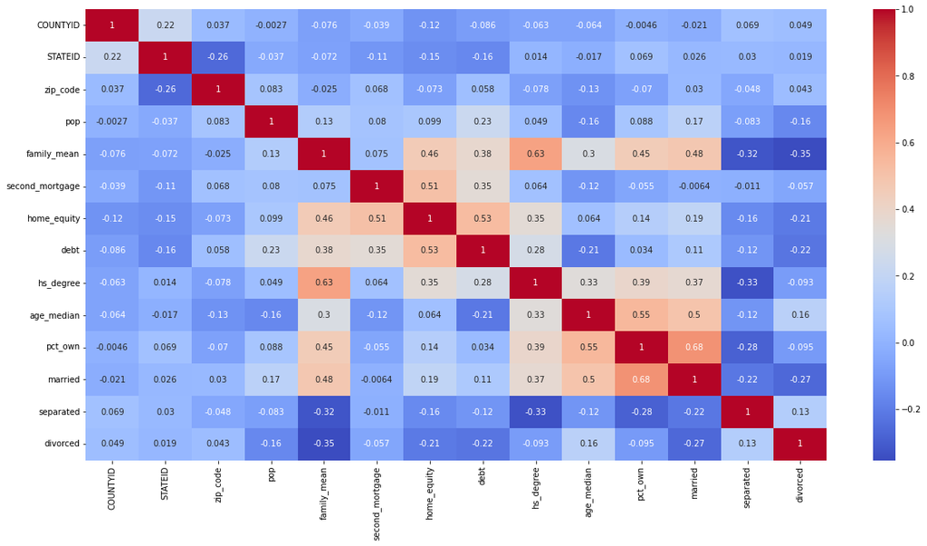

```python
plt.figure(figsize=(20,10))
sns.heatmap(cor,annot=True,cmap='coolwarm')
plt.show()
```

Project Task: Week 2

Data Pre-processing:

1)The economic multivariate data has a significant number of measured variables. The goal is to find where the measured variables depend on a number of smaller unobserved common factors or latent variables.

```python
#same we have to show the relation between the numeric variables so we should plot a heatmap
```

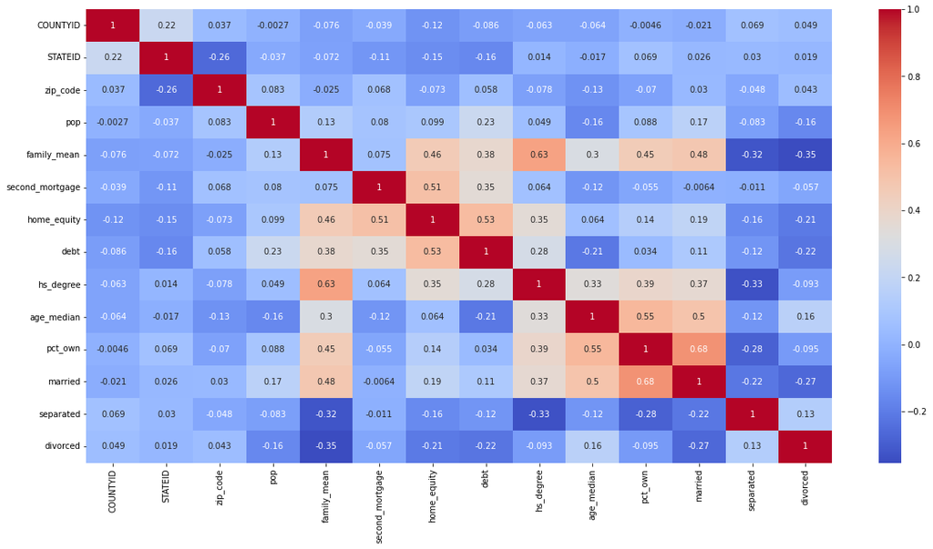

```python
plt.figure(figsize=(20,10))
sns.heatmap(cor,annot=True,cmap='coolwarm')
plt.show()
```

```python
from sklearn.decomposition import FactorAnalysis
from factor_analyzer import FactorAnalyzer
```

```python
fa = FactorAnalyzer(n_factors=5)
fa.fit_transform(df_train.select_dtypes(exclude=('object','category')))
fa.loadings_
```

```
array([[-0.0792116 ,  0.01842369, -0.00226993, -0.20615037,  0.1225752 ],
       [-0.10984742,  0.02069069, -0.02864267, -0.07473645,  0.04769891],
       [-0.10239309,  0.01738258,  0.01114895, -0.19315079,  0.1354283 ],
       [-0.08622375,  0.0503972 , -0.12586024, -0.03474273, -0.11990474],
       [ 0.01793293,  0.01939809,  0.0050148 ,  0.02432589, -0.00404004],
       [ 0.09338584, -0.09600445, -0.06490774, -0.14554334, -0.14514437],
       [-0.00633166, -0.03983021,  0.13510123, -0.00869712,  0.12448944],
       [-0.04107781, -0.02151263,  0.03726748, -0.08926393,  0.05508894],
       [-0.00171758, -0.01561247, -0.00212012, -0.0419514 ,  0.02096203],
       [ 0.08106246,  0.95705899, -0.08717159, -0.00931178, -0.04671674],
       [ 0.07608831,  0.91836258, -0.1085829 , -0.03001101, -0.04734035],
       [ 0.082143  ,  0.94745463, -0.06115377,  0.01212778, -0.04428319],
       [ 0.76885592,  0.00988416, -0.03762533,  0.1174266 , -0.12008072],
       [ 0.71734364,  0.00632598, -0.0459031 ,  0.11114238, -0.13198297],
       [ 0.70736917,  0.0243711 , -0.01587398,  0.11013978,  0.08010933],
       [-0.13355613,  0.33709503, -0.49760616, -0.03972315,  0.30306628],
       [ 0.23210401,  0.437876  , -0.65226167, -0.0200922 ,  0.32888845],
       [-0.05580329,  0.03583347,  0.03246145,  0.4366301 , -0.15056769],
       [-0.04080349,  0.01784958,  0.04593498,  0.66701643, -0.13686787],
       [-0.05801688, -0.01587141,  0.07881548,  0.82689595, -0.06875887],
       [-0.07195459, -0.03483021,  0.10612726,  0.91516163, -0.01847966],
       [-0.08172944, -0.04331598,  0.13018176,  0.94287774,  0.00519926],
       [-0.06590128, -0.0516997 ,  0.13462042,  0.92281737,  0.02727529],
       [-0.0609732 , -0.05820722,  0.12238364,  0.87804466,  0.0366067 ],
       [-0.04133601, -0.0721883 ,  0.08774525,  0.77123172,  0.05230314],
       [ 0.21339998,  0.46601796, -0.62687394, -0.01913859,  0.34840308],
       [ 0.23410295,  0.44716267, -0.64011127, -0.02191105,  0.32514045],
       [ 0.79238621,  0.04905938,  0.14490124, -0.20614814, -0.15126371],
       [ 0.71742326,  0.0500319 ,  0.13453752, -0.22160945, -0.20765805],
       [ 0.86795577,  0.04307742,  0.1605773 , -0.11635554,  0.03598535],
       [-0.22395172,  0.84529556, -0.05126505,  0.07183175,  0.21973536],
       [ 0.14725001,  0.9523349 ,  0.0189972 , -0.04532103,  0.09437434],
       [ 0.83812198,  0.03405856,  0.15868735, -0.20460415, -0.07091735],
       [ 0.80228398,  0.02831945,  0.14929209, -0.20850365, -0.08730564],
       [ 0.81717901,  0.04281505,  0.1378293 , -0.10416641,  0.06167721],
       [-0.33943428,  0.86410906,  0.03680041,  0.09068834,  0.0391315 ],
       [ 0.05280027,  0.93477693,  0.15372361, -0.02847888, -0.09559074],
       [ 0.98025046, -0.03302912, -0.11356736,  0.04886398,  0.07656873],
       [ 0.9610857 , -0.03881021, -0.12879742,  0.04855517,  0.06923244],
       [ 0.81621945,  0.00156498,  0.06981636,  0.02877682,  0.13001142],
```

[output cut: 20 more lines]

```
       [ 0.05786199,  0.81783653, -0.1790561 , -0.01883945, -0.0411379 ],
       [ 0.0737649 ,  0.9230537 , -0.10681102, -0.03016369, -0.05150909],
       [ 0.19103863, -0.0502201 ,  0.79771844,  0.16033634,  0.34683896],
       [ 0.18639627, -0.03556971,  0.85484822,  0.14638686,  0.27020893],
       [-0.10331912,  0.05918564,  0.47234358,  0.07837232,  0.12053133],
       [ 0.06290757,  0.87793498, -0.15153852,  0.01710213, -0.04742488],
       [ 0.07985872,  0.95413778, -0.05939517,  0.01297845, -0.04869587],
       [-0.03013645,  0.11014075,  0.79395491, -0.0480813 , -0.26421039],
       [ 0.18061544,  0.18936164,  0.56671283, -0.11976539, -0.12449522],
       [-0.06738151, -0.07014381, -0.2740293 ,  0.13303146,  0.18361138],
       [-0.15941157, -0.07058704, -0.14998787,  0.12545655,  0.14518508],
       [-0.35923471, -0.05390176,  0.14943665,  0.03572036,  0.11087073],
       [ 0.23564757, -0.02770837, -0.01519566,  0.09402702, -0.65195479],
       [ 0.35078989, -0.00986252, -0.4080927 ,  0.06108151,  0.28723433],
       [ 0.22493634, -0.0369958 ,  0.8896242 ,  0.12864748,  0.28152319]])
```

Data Modeling :

Build a linear Regression model to predict the total monthly expenditure for home mortgages loan.

```
   Please refer deplotment_RE.xlsx. Column hc_mortgage_mean is predicted variable. This is the mean monthly mortgage and owner costs of specified geographical location.

   Note: Exclude loans from prediction model which have NaN (Not a Number) values for hc_mortgage_mean.

   a) Run a model at a Nation level. If the accuracy levels and R square are not satisfactory proceed to below step.

   b) Run another model at State level. There are 52 states in USA.

   c) Keep below considerations while building a linear regression model:
```

Variables should have significant impact on predicting Monthly mortgage and owner costs